# Travail pratique 1 de Computer Vision

### Réalisé par

Nom : MULAPI TITA

Prénom : Ketsia

Promotion : Master 1, SD.

## 0) Importation des librairies

```python
!pip install opencv-python
```

```python
from skimage import filters
from skimage import data, io, morphology
from skimage.io import imread
import matplotlib.pyplot as plt
import numpy as np
import io
```

```python
import cv2
```

```python
from scipy.ndimage.measurements import label
from skimage.filters import sobel
from skimage import measure
from skimage.segmentation import clear_border, watershed
from skimage.color import label2rgb
```

```python
import sys
```

```python
from scipy import misc
```

```python
from PIL import Image, ImageOps
```

```python
import skimage.morphology as skimorph
from ipywidgets import interact, interact_manual
```

## 1) Les fonctions

```python
def lever_exception(f):
    '''
    cette méthode pemret de lever une exception
    en focntion d'une méthode bien précise
    '''
    raise Exception("Il y'a un problème au niveau de la fonction ",f)
```

```python
def all_or_nothing(img1, img2, Op):
    '''
    Cette fonction permet d'appliquer des opérations
    logiques sur les images.
    Union et Intersection : 2 images recquises
    Complémentarité : 1 image suffit
    | : la barre de sheffer pour le ou-exclusif
    Op : Opération
    '''

    assert img1.shape == img2.shape
    assert Op == "U" or \
        Op == "|" or \
        Op == "^" or \
        Op == "C"

    dimx, dimy = img1.shape
    image_resultante = np.zeros((dimx,dimy))

    # OU EXCLUSIF & INTERSECTION
    for i in range(dimx) :
        for j in range(dimy) :

            # UNION (OU INCLUSIF ::: U)
            if Op == "U":
                image_resultante[i,j] = img1[i,j]+img2[i,j]

            # EXCLUSION (OU EXCLUSIF ::: | )
            if Op == "|":
                if (img1[i,j] == 0 and img2[i,j] == 255) or \
                    (img1[i,j] == 255 and img2[i,j] == 0):
                    image_resultante[i,j] = 255

            # INTERSECTION (ET ::: ^ )
            if Op == "^":
                if img1[i,j]==img2[i,j]:
                    image_resultante[i,j] = 255

    # COMPLEMENTARITÉ (C ::: C)
    if Op == "C":
        image = np.zeros(img1.shape)
        image = img1[:,:]
        return 255 - image

    return image_resultante
```

```python
def otsu_th(im):
    '''
    Cette méthode permet d'appliquer un processus de seuillage sur une image :
    réalisé dans le cours de représentation des données, le seuillage par Otsu
    est basé sur le calcul de la variance intra-classe.
    '''
    assert len(im.shape) == 2
    bins = [np.count_nonzero(im==i)for i in range(256)]
    dim=im.size
    seuil=256
    sm=None
    sgm=[]
    #
    for i in range(256):
        class1 = im[np.where(im<=i)]
        class2 = im[np.where(im>i)]
        #
        O = (len(class1)/dim,len(class2)/dim)
        #
        if class1.size == 0 :
            class1 = [0]
        if class2.size == 0 :
            class2 = [0]
        var_ = (np.var(class1),np.var(class2))
        #
        sg = O[1]*var_[1]+O[0]*var_[0]
        sgm.append(sg)
        if sm is None or sg < sm :
            sm = sg
            seuil = i
    return seuil, sgm
```

```python
def get_Image_gray(Ze_path):
    '''
    Cette méthode retourne une image en 2 dimensions,
    que celle-ci soit en couleur RGB et donc à 3 dimensions, en NDG ou Binaire.
    '''
    assert type(Ze_path) == str
    return imread(Ze_path,as_gray=True)
```

```python
def print_img(img,title):
    '''
    Cette méthode permet d'afficher une image en NDG ainsi que sa taille !
    '''
    assert type(title) == str and len(img.shape) == 2
    print("la taille de ",title," est : ",img.shape)
    plt.title(title)
    plt.imshow(img,cmap="gray")
```

```python
def convert_binary(image_src, thresh_val):
    '''
    Cette méthode permet d'appliquer le seuil, obtenu à l'aide de Otsu,
    sur une image, afin de renvoyer une image binaire.
    # Nota Bene : code source pris sur internet (source oubliée) !
    '''
    assert len(image_src.shape) == 2 and type(thresh_val) != str
    color_1 = 255
    color_2 = 0
    initial_conv = np.where((image_src <= thresh_val), image_src, color_1)
    final_conv = np.where((initial_conv > thresh_val), initial_conv, color_2)
    return final_conv
```

```python
def UnFiltreE(img, filtre, kernel_i, kernel_j):
    '''
    Cette methode permet de renvoyer un filtre adaptée à
    une opération d'érosion, elle donne la possibilité d'appliquer un élément structurant
    en croix, en X, en rectangle verticale et horizontale, Complet (3x3)
    p.s. : pas très optimale c'est vrai mais bon, ça marche bien.
    '''
    assert len(img.shape) == 2 and type(filtre) == str
    if filtre == "Croix":
        if img[kernel_i-1][kernel_j] != 0 and img[kernel_i][kernel_j-1]!=0 and  \
            img[kernel_i+1][kernel_j] != 0 and img[kernel_i][kernel_j + 1] != 0 \
            and img[kernel_i][kernel_j] != 0 :
            return 255
    if filtre == "X":
        if img[kernel_i-1][kernel_j-1] != 0 and img[kernel_i-1][kernel_j+1]!=0 and  \
            img[kernel_i+1][kernel_j-1] != 0 and img[kernel_i+1][kernel_j + 1] != 0 \
            and img[kernel_i][kernel_j] != 0 :
            return 255
    if filtre == "RV":
        if img[kernel_i-1][kernel_j] != 0 and img[kernel_i+1][kernel_j] != 0 and img[kernel_i][kernel_j] != 0 :
            return 255
    if filtre == "RH":
        if img[kernel_i][kernel_j-1] != 0 and img[kernel_i][kernel_j+1] != 0 and img[kernel_i][kernel_j] != 0 :
            return 255
    if filtre == "Complet":
        if img[kernel_i-1][kernel_j-1] != 0 and img[kernel_i-1][kernel_j] != 0 and img[kernel_i-1][kernel_j+1]!=0 \
            and img[kernel_i][kernel_j-1] != 0 and img[kernel_i][kernel_j] != 0 and img[kernel_i][kernel_j + 1] != 0 \
            and img[kernel_i+1][kernel_j-1] != 0 and img[kernel_i+1][kernel_j] != 0 and img[kernel_i+1][kernel_j+1] != 0:
            return 255
    if filtre == "B2":
        if img[kernel_i-1][kernel_j-1] != 0 and img[kernel_i-1][kernel_j] != 0 and img[kernel_i-1][kernel_j+1]!=0 \
            and img[kernel_i][kernel_j-1] != 0 and img[kernel_i][kernel_j] != 0 and img[kernel_i][kernel_j + 1] != 0 \
            and img[kernel_i+1][kernel_j-1] != 0 and img[kernel_i+1][kernel_j] != 0 and img[kernel_i+1][kernel_j+1] != 0 \
            and img[kernel_i-2][kernel_j-2] != 0 and img[kernel_i-2][kernel_j-1] != 0 and img[kernel_i-2][kernel_j+2]!=0 \
            and img[kernel_i+2][kernel_j-2] != 0 and img[kernel_i+2][kernel_j] != 0 and img[kernel_i+2][kernel_j+2] != 0:
            return 255
    return 0
```

```python
def UnFiltreD(img, filtre, kernel_i, kernel_j):
    '''
    Cette methode permet de renvoyer un filtre adaptée à
    une opération de dilatation, elle donne la possibilité d'appliquer un élément structurant
    en croix, en X, en rectangle verticale et horizontale, Complet (3x3)
    p.s. : pas très optimale c'est vrai mais bon, ça marche bien.
    '''
    assert len(img.shape) == 2 and type(filtre) == str
    if filtre == "Croix":
        if img[kernel_i-1][kernel_j] != 0 or img[kernel_i][kernel_j-1]!=0 or  \
            img[kernel_i+1][kernel_j] != 0 or img[kernel_i][kernel_j + 1] != 0 \
            or img[kernel_i][kernel_j] != 0 :
            return 255
    if filtre == "X":
        if img[kernel_i-1][kernel_j-1] != 0 or img[kernel_i-1][kernel_j+1]!=0 or  \
            img[kernel_i+1][kernel_j-1] != 0 or img[kernel_i+1][kernel_j + 1] != 0 \
            or img[kernel_i][kernel_j] != 0 :
            return 255
    if filtre == "RV":
        if img[kernel_i-1][kernel_j] != 0 or img[kernel_i+1][kernel_j] != 0 or img[kernel_i][kernel_j] != 0 :
            return 255
    if filtre == "RH":
        if img[kernel_i][kernel_j-1] != 0 or img[kernel_i][kernel_j+1] != 0 or img[kernel_i][kernel_j] != 0 :
            return 255
    if filtre == "Complet":
        if img[kernel_i-1][kernel_j-1] != 0 or img[kernel_i-1][kernel_j] != 0 or img[kernel_i-1][kernel_j+1]!=0 \
            or img[kernel_i][kernel_j-1] != 0 or img[kernel_i][kernel_j] != 0 or img[kernel_i][kernel_j + 1] != 0 \
            or img[kernel_i+1][kernel_j-1] != 0 or img[kernel_i+1][kernel_j] != 0 or img[kernel_i+1][kernel_j+1] != 0:
            return 255
    if filtre == "B2":
        '''
        Pas optimal certe mais ça marche ...
        '''
        if img[kernel_i-3][kernel_j-3] != 0 or img[kernel_i-3][kernel_j] != 0 or img[kernel_i-3][kernel_j+3]!=0 \
            or img[kernel_i-1][kernel_j-1] != 0 or img[kernel_i-1][kernel_j] != 0 or img[kernel_i-1][kernel_j+1]!=0 \
            or img[kernel_i][kernel_j-1] != 0 or img[kernel_i][kernel_j] != 0 or img[kernel_i][kernel_j + 1] != 0 \
            or img[kernel_i+1][kernel_j-1] != 0 or img[kernel_i+1][kernel_j] != 0 or img[kernel_i+1][kernel_j+1] != 0 \
            or img[kernel_i-2][kernel_j-2] != 0 or img[kernel_i-2][kernel_j-1] != 0 or img[kernel_i-2][kernel_j+2]!=0 \
            or img[kernel_i+2][kernel_j-2] != 0 or img[kernel_i+2][kernel_j] != 0 or img[kernel_i+2][kernel_j+2] != 0 \
            or img[kernel_i+3][kernel_j+3] != 0 or img[kernel_i+3][kernel_j] != 0 or img[kernel_i+3][kernel_j+3]!=0 \
            or img[kernel_i][kernel_j-2] != 0 or img[kernel_i][kernel_j + 2] != 0 \
            or img[kernel_i][kernel_j-3] != 0 or img[kernel_i][kernel_j + 3] != 0:
            return 255
    return 0
```

```python
def myErosion(im, Kernel):
    '''
    Cette méthode a pour but de mettre en
    oeuvre une fonction d'érosion
    '''
    assert len(im.shape) == 2 and type(Kernel) == str
    image = np.copy(im)
    xdim,ydim = image.shape
    # Etape 1 : A l'image de notre cours d'HPC (High Performance Computing),
    # voici une façonn pour nous de créer des zones fictives ou fantômes,
    # au voisinage des bordures.
    res_grid = np.zeros((xdim + 2,ydim + 2),dtype=int)
    res_grid[1:xdim + 1,1:ydim + 1] = image[:,:]
    # Etape 2 Ici on commence à appliquer l'érosion en utilisant un filtre en particulier
    img = [UnFiltreE(res_grid, Kernel, i, j) for j in range(1, ydim) for i in range(1, xdim)]
    for i in range(1, xdim):
        for j in range(1, ydim):
            image[i,j] = UnFiltreE(res_grid, Kernel, i, j)
    return image, img
```

```python
def myDilatation(im, Kernel):
    '''
    Cette méthode a pour but de mettre en
    oeuvre une fonction de dilatation
    '''
    assert len(im.shape) == 2 and type(Kernel) == str
    image = np.copy(im)
    xdim,ydim = image.shape
    # Etape 1 : A l'image de notre cours d'HPC (High Performance Computing),
    # voici une façonn pour nous de créer des zones fictives ou fantômes,
    # au voisinage des bordures.
    res_grid = np.zeros((xdim + 2,ydim + 2),dtype=int)
    res_grid[1:xdim + 1,1:ydim + 1] = image[:,:]
    # Etape 2 Ici on commence à appliquer l'érosion en utilisant un filtre en particulier
    img = [UnFiltreD(res_grid, Kernel, i, j) for j in range(1, ydim) for i in range(1, xdim)]
    for i in range(1, xdim):
        for j in range(1, ydim):
            image[i,j] = UnFiltreD(res_grid, "Croix", i, j)
    return image, img
```

```python
def degree_of_interior(img):
    '''
    renvoie une image érodé plusisuers fois !!!
    '''
    #lever_exception(f)
    imgE = np.copy(img)
    for i in range(6):
        imgE, img_coord = myErosion(imgE,"Croix")
    return imgE #NotImplemented
```

```python
def squelette(img, invert=False):
    '''
    Cette méthode, utilise :
    librairie : skimage
    module : morphology
    classe :skimorph
    method : skeletonize
    '''
    # Binarisation
    img = np.array(1.0 * (np.array(img) > 127), dtype="uint8")
    # obtention de la morphologie
    morphed = skimorph.skeletonize(img == 1)
    # Visualisaons
    fig = plt.figure(figsize=(12, 6))
    plt.subplot(121), plt.imshow(img, cmap='gray'), plt.title("Originale")
    plt.subplot(122), plt.imshow(morphed, cmap='gray'), plt.title("Resultat : squelette")
    plt.show()
```

```python
def morpho_math_ndg(f):
    '''
    Déjà fait !!!
    '''
    lever_exception(f)
    return NotImplemented
```

## 2) Morpho math Experience

### 2.1.0) Ouverture d'image

> RETENONS que image_yin_yang_noisy est **notre image 1**

```python
image_yin_yang_noisy = get_Image_gray("noisy_yin_yang.png")
```

```
la taille de  l'image originale  est :  (1200, 1200)
```

[figure not shown]

```python
print_img(image_yin_yang_noisy,"l'image originale")
```

> RETENONS que image_yin_yang est **notre image 2**

```
la taille de  l'image originale sans bruit  est :  (1200, 1200)
```

[figure not shown]

```python
image_yin_yang = get_Image_gray("yin_yang.png")
print_img(image_yin_yang,"l'image originale sans bruit")
```

> RETENONS que image_qr -> new_img est **notre image 3**

```
la taille de  l'imag originale QR  est :  (300, 300)
```

[figure not shown]

```python
image_qr = get_Image_gray("QRCode.png")
print_img(image_qr,"l'imag originale QR")
```

### 2.1.1 Tout ou rien

```python
image_yin_yang_noisy.shape
```

```
(1200, 1200)
```

```python
image_yin_yang.shape
```

```
(1200, 1200)
```

```python
image_qr.shape
```

```
(300, 300)
```

Redimenssionnement

```python
new_img = cv2.resize(image_qr, image_yin_yang.shape)
```

```
la taille de  l'image qr_code redimensionée  est :  (1200, 1200)
```

[figure not shown]

```python
print_img(new_img,"l'image qr_code redimensionée")
```

### Union

```python
image_resultante = all_or_nothing(image_yin_yang_noisy, new_img, "U")
```

```
la taille de  l'union de 2 images  est :  (1200, 1200)
```

[figure not shown]

```python
print_img(image_resultante,"l'union de 2 images")
```

l'opération d'union entre 2 images, permet la fusion de ces 2 images et, lorsqu'on les fusionne les pixels blancs ont tendances à être beaucoup plus présent dans l'image résulante. Fusion entre l'image 3 et 1.

### Intersection

```python
image_resultante = all_or_nothing(new_img, image_yin_yang, "^")
```

```
la taille de  l'intersection de 2 images  est :  (1200, 1200)
```

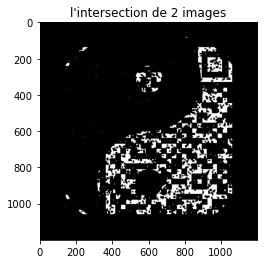

```python
print_img(image_resultante,"l'intersection de 2 images")
```

Intersection entre les images 2 et 3.

L'intersection entre 2 images, met en avant tous les pixels noirs qui coïncide, en blanc.

#### Complémentarité

```python
image_resultante = all_or_nothing(new_img, image_yin_yang_noisy, "C")
```

```
la taille de  l'image complémentaire du QR_code  est :  (1200, 1200)
```

[figure not shown]

```python
print_img(image_resultante,"l'image complémentaire du QR_code")
```

```
la taille de  l'image complémentaire du yin_yang sans bruit  est :  (1200, 1200)
```

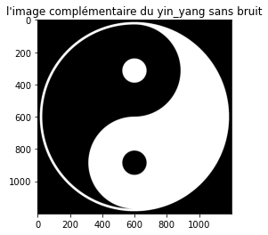

```python
image_resultante = all_or_nothing(image_yin_yang,new_img, "C")
print_img(image_resultante,"l'image complémentaire du yin_yang sans bruit")
```

Le complémentaire d'une image est son inverse.

#### Ou exclusif

```python
image_resultante = all_or_nothing(image_yin_yang, image_yin_yang_noisy, "|")
```

```
la taille de  l'application d'un ou-exclusif à 2 images  est :  (1200, 1200)
```

[figure not shown]

```python
print_img(image_resultante,"l'application d'un ou-exclusif à 2 images")
```

Cette opération de Ou exclusif s'intérresse à l'ensemble des pixels ayant un point commun aussi bien dans l'une des images que dans l'autre.

```
la taille de  l'image complémentaire image_yin_yang  est :  (1200, 1200)
```

[figure not shown]

```python
image_resultante = all_or_nothing(image_yin_yang_noisy, image_yin_yang, "C")
print_img(image_resultante,"l'image complémentaire image_yin_yang")
```

```
la taille de  l'union de image_yin_yang et son complémentaire  est :  (1200, 1200)
```

[figure not shown]

```python
image_resultante = all_or_nothing(image_yin_yang, image_resultante, "U")
print_img(image_resultante,"l'union de image_yin_yang et son complémentaire")
```

On a l'ensemble des pixels noirs des 2 images : le bruit et les pixels blancs et noirs.

#### A ^ C(A) = Ensemble Vide

```
la taille de  l'image complémentaire image_yin_yang  est :  (1200, 1200)
```

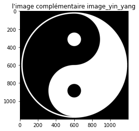

```python
image_resultante = all_or_nothing(image_yin_yang, image_yin_yang, "C")
print_img(image_resultante,"l'image complémentaire image_yin_yang")
```

```
la taille de  l'intersection de 2 images  est :  (1200, 1200)
```

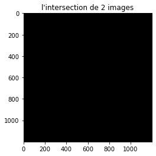

```python
image_resultante = all_or_nothing(image_yin_yang, image_resultante, "^")
print_img(image_resultante,"l'intersection de 2 images")
```

```
la taille de  l'image C(A) U C(B)  est :  (1200, 1200)
```

[figure not shown]

```python
image_resultante1 = all_or_nothing(new_img, new_img, "C") # C(A)
image_resultante2 = all_or_nothing(image_yin_yang_noisy, image_yin_yang_noisy, "C") # C(B)
image_resultante3 = all_or_nothing(image_resultante1, image_resultante2, "U") # C(A) U C(B)
print_img(image_resultante3,"l'image C(A) U C(B)")
```

```
la taille de  l'image C(AUB)  est :  (1200, 1200)
```

[figure not shown]

```python
image_resultante = all_or_nothing(new_img, image_yin_yang_noisy, "U") # AUB
image_resultante2 = all_or_nothing(image_resultante, image_yin_yang_noisy, "C") # C(AUB)
print_img(image_resultante2,"l'image C(AUB)")
```

```
la taille de  l'image C(A) ^ C(B)  est :  (1200, 1200)
```

[figure not shown]

```python
image_resultante1 = all_or_nothing(new_img, new_img, "C") # C(A)
image_resultante2 = all_or_nothing(image_yin_yang_noisy, image_yin_yang_noisy, "C") # C(B)
image_resultante3 = all_or_nothing(image_resultante1, image_resultante2, "^") # C(A) ^ C(B)
print_img(image_resultante3,"l'image C(A) ^ C(B)")
```

```
la taille de  l'image C(A^B)  est :  (1200, 1200)
```

[figure not shown]

```python
image_resultante = all_or_nothing(new_img, image_yin_yang_noisy, "^") # AUB
image_resultante2 = all_or_nothing(image_resultante, image_yin_yang_noisy, "C") # C(A^B)
print_img(image_resultante2,"l'image C(A^B)")
```

### 2.1.2 Erosion

```python
img, img_coord = myErosion(image_yin_yang_noisy, "Croix")
```

```
la taille de  Erosion-Croix-YY_noisy  est :  (1200, 1200)
```

[figure not shown]

```python
print_img(img, "Erosion-Croix-YY_noisy")
```

```
la taille de  Erosion-Croix-QR_code  est :  (300, 300)
```

[figure not shown]

```python
img, img_coord = myErosion(image_qr, "Croix")
print_img(img, "Erosion-Croix-QR_code")
```

```
la taille de  Erosion-X-QR_code  est :  (300, 300)
```

[figure not shown]

```python
img, img_coord = myErosion(image_qr, "X")
print_img(img, "Erosion-X-QR_code")
```

L'image Erodé : on a plus de pixel noir accentué que de pixel blanc et de bruit blanc.

### 2.1.3 Dilatation

```python
img, img_coord = myDilatation(image_yin_yang_noisy, "Croix")
```

```
la taille de  Dilatation-Croix-YY_noisy  est :  (1200, 1200)
```

[figure not shown]

```python
print_img(img, "Dilatation-Croix-YY_noisy")
```

```
la taille de  Dilatation-Croix-QR_code  est :  (300, 300)
```

[figure not shown]

```python
img, img_coord = myDilatation(image_qr, "Croix")
print_img(img, "Dilatation-Croix-QR_code")
```

```
la taille de  Dilatation-X-YY_noisy  est :  (1200, 1200)
```

[figure not shown]

```python
img, img_coord = myDilatation(image_yin_yang_noisy, "X")
print_img(img, "Dilatation-X-YY_noisy")
```

```
la taille de  Dilatation-Complet-QR_code  est :  (300, 300)
```

[figure not shown]

```python
img, img_coord = myDilatation(image_qr, "Complet")
print_img(img, "Dilatation-Complet-QR_code")
```

L'image Dilaté : on a plus de pixel blanc accentué que de pixel noir et de bruit noir.

### 2.1.4 Manipulation

EROSION : Comme vu dans l'exercice précédent 2.1.3, on peut s'apercevoir que plus l'élément strcuturant est petit il est plus facile de se rapprocher de l'image originale, plus l'élément structurant est grand moins on se rapproche de l'image originale.

A l'inverse : nous dilatons.

```python
imgE, img_coord = myErosion(image_yin_yang_noisy, "Croix")
imgD, img_coord = myDilatation(image_yin_yang_noisy, "Croix")
```

```
la taille de  Image_Dilate - Image_Originale = Contour  est :  (1200, 1200)
```

[figure not shown]

```python
print_img(imgD - image_yin_yang_noisy, "Image_Dilate - Image_Originale = Contour")
```

les pixels blancs sont obtenu par inversion, les pixel noirs sont obtenu par modification

b) Originale - Erodé = contour noir.

```
la taille de  Image_Dilate - Image_Originale = Contour  est :  (1200, 1200)
```

[figure not shown]

```python
print_img(image_yin_yang_noisy - imgE, "Image_Dilate - Image_Originale = Contour")
```

On passe du blanc au noir (inversion), pixel blanc modifié, inverse du précédent.

##### Montrons qu'en faisant une double érosion, on obtient exactement une érosion avec un plus grand élement structurant de même forme, ici on se refaire au complet ! :

```
la taille de  Image_Erodé W/ elt struct. B2  est :  (1200, 1200)
```

[figure not shown]

```python
imgD, img_coord = myErosion(image_yin_yang_noisy, "B2")
print_img(imgD, "Image_Erodé W/ elt struct. B2")
```

```
la taille de  Image_Erodé W/ elt struct. Complet  est :  (1200, 1200)
```

[figure not shown]

```python
imgD, img_coord = myErosion(image_yin_yang_noisy, "Complet")
imgD, img_coord = myErosion(imgD, "Complet")
print_img(imgD, "Image_Erodé W/ elt struct. Complet")
```

Pas aussi proche que ça finalement !!!